# Corporate Bonds — A Practical Primer

Everything You Need to Know Before You Buy Your First Bond

Author

Tor Storli and  
Claude Sonnet 4.6 (Anthropic’s AI assistant)

Published

July 7, 2026

## What Is a Bond?

A bond is simply a **loan** — but instead of borrowing from a bank, a company borrows from thousands of individual and institutional investors simultaneously. When you buy a corporate bond you are the lender. The company is the borrower. In return for lending your money, the company promises to:

1. Pay you a fixed **coupon** (interest) at regular intervals
2. Return your full **principal** (face value) on the **maturity date**

That’s it. A bond is a legally binding IOU.

**NoteA Simple Example**

Apple Inc needs $5 billion to fund a new manufacturing facility. Rather than taking out a single bank loan, Apple issues 5,000,000 bonds at $1,000 each. Investors around the world buy these bonds. Apple pays each bondholder 4% annual interest ($40 per year, paid $20 every six months) and returns the $1,000 principal in 10 years.

## Stocks vs Bonds — What Is the Difference?

This is the question most first-time investors ask. The answer comes down to one word: **ownership**.

|  | Stock | Bond |
| --- | --- | --- |
| What you are | **Owner** of the company | **Lender** to the company |
| Your return | Dividends (if paid) + price appreciation | Fixed coupon payments |
| Your risk | Company performs badly → stock falls to zero | Company defaults → may not get paid back |
| Your upside | Unlimited — stock can rise 10×, 100× | Capped — you get the coupon and your money back |
| Your priority if the company goes bankrupt | **Last in line** | **Ahead of stockholders** |
| Certainty of income | None — dividends can be cut | High — coupon is contractually fixed |

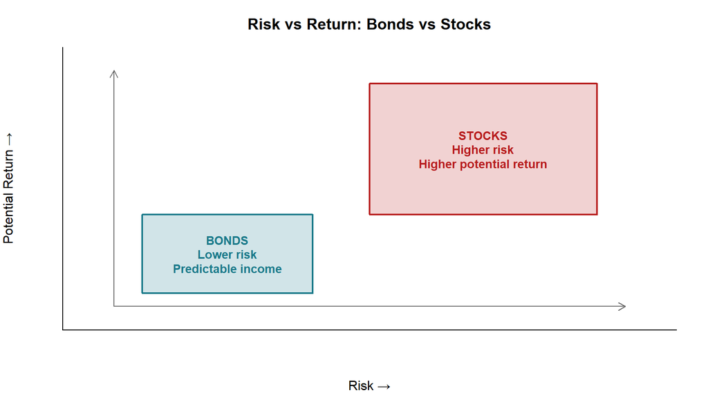

The key takeaway: bonds are not exciting. They are **predictable**. For an investor who needs steady income — a retiree, a pension fund, an insurance company — that predictability is exactly what they want.

## How Are Corporate Bonds Issued?

### The Investment Bank: The Middleman

A company does not sell bonds directly to the public by itself. It hires one or more **investment banks** (also called underwriters) to manage the entire process. Major underwriters include Goldman Sachs, JPMorgan, Morgan Stanley, Bank of America, and Citigroup.

The investment bank’s job is to:

1. **Structure the deal** — help the company decide the coupon rate, maturity, size of the offering, and terms
2. **Price the bond** — determine what yield investors will demand
3. **Build the book** — contact institutional investors (pension funds, insurance companies, mutual funds) to gauge demand
4. **Distribute the bonds** — sell them to investors
5. **Make a market** — often commit to buying and selling the bonds after issuance to provide liquidity

The investment bank earns an **underwriting fee** — typically 0.5% to 1.5% of the total offering size. On a $1 billion bond issue that is $5 million to $15 million in fees.

### Firm Commitment vs Best Efforts

There are two main underwriting arrangements:

**Firm Commitment** — the investment bank buys the entire bond issue from the company at a guaranteed price and then resells to investors. The bank takes the risk that it cannot sell all the bonds at the expected price. This is the most common arrangement for large, well-known companies.

**Best Efforts** — the investment bank acts as agent only, selling as many bonds as it can at the best available price. The company bears the risk that the full amount is not raised. Common for smaller or riskier issuers.

### How Long Does It Take?

The timeline from decision to cash in the bank is typically:

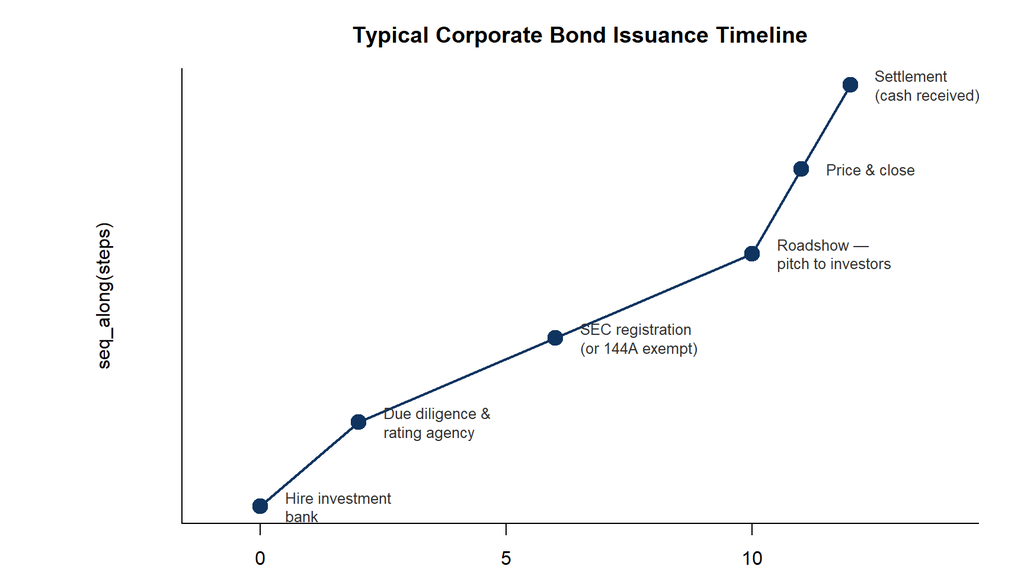

The entire process for an investment-grade bond typically takes **8 to 12 weeks** from the initial decision to cash in the bank. A **Rule 144A** private placement (exempt from full SEC registration) can close in as little as **2 to 3 weeks** since it targets sophisticated institutional investors only.

### Typical Denominations

Corporate bonds are typically issued in minimum denominations of **$1,000** (the “par value” or “face value”). However, the practical minimum investment is usually **$5,000 or $10,000** in the secondary market. Institutional bonds often trade in blocks of $1 million or more.

| Investor type | Typical minimum |
| --- | --- |
| Individual retail investor | $1,000 – $5,000 |
| Brokerage platform | $1,000 – $10,000 |
| Institutional (pension/insurance) | $1,000,000+ |

## How Is the Coupon Rate Determined?

The coupon rate is set at issuance based on **what yield investors require** for that specific bond. That required yield depends on three factors:

### 1. The Risk-Free Rate

The starting point is the yield on a US Treasury bond of the same maturity — the “risk-free” rate. As of June 2026 the 10-year Treasury yields approximately 4.44%.

### 2. The Credit Spread

On top of the risk-free rate, investors demand a **credit spread** — extra yield to compensate for the risk that the company might not pay them back. The spread depends on the company’s credit rating.

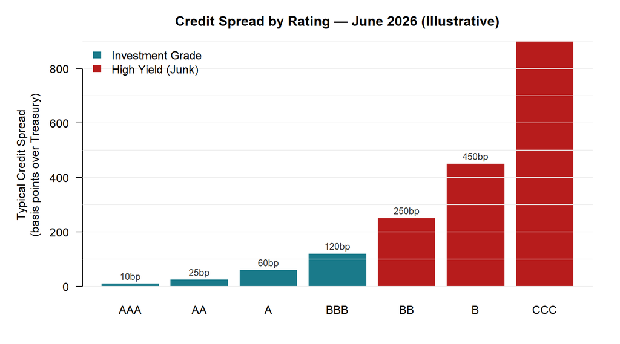

### 3. Market Conditions at Issuance

Even after rating and risk-free rate are known, the final coupon depends on **live market conditions** on pricing day — investor demand, competing supply of new bonds, and general market sentiment. A company issuing on a volatile day may need to offer a higher coupon to attract buyers.

**NoteA Real-World Example**

Suppose Apple (rated AAA) wants to issue a 10-year bond in June 2026.

- 10-year Treasury yield: 4.44%
- Typical AAA spread: ~10 bp
- Indicated coupon: **4.44% + 0.10% = ~4.54%**

Apple might set the coupon at 4.50% rounded. If investor demand is exceptionally strong (“oversubscribed”) the spread could compress to 5 bp and the coupon land at 4.49%. If demand is weak it might need to be 4.60% to attract enough buyers.

## What Types of Corporate Bonds Are There?

Not all bonds are created equal. The key distinction is **what backs the bond** — what investors can claim if the company fails to pay.

### Secured Bonds

A **secured bond** is backed by specific assets pledged as collateral. If the company defaults, bondholders can seize those assets and sell them to recover their investment.

**Mortgage bonds** — backed by real property (buildings, land, equipment). The most common type of secured corporate bond. If the company defaults, bondholders have first claim on those properties.

**Equipment trust certificates** — backed by specific equipment, common in airlines (backed by aircraft) and railroads (backed by rolling stock).

**Collateral trust bonds** — backed by financial assets such as stocks and bonds of subsidiaries.

### Unsecured Bonds (Debentures)

A **debenture** is backed only by the general creditworthiness of the company — not by any specific asset. If the company defaults, debenture holders join the general pool of unsecured creditors.

Most investment-grade corporate bonds are debentures. When you buy an Apple, Microsoft, or Amazon bond, you are buying a debenture — you are trusting the company’s cash flows and financial strength, not a specific asset.

**Subordinated debentures** — rank below regular debentures in priority. Higher risk = higher coupon.

### Convertible Bonds

A **convertible bond** gives the holder the option to convert the bond into shares of company stock at a predetermined price. Investors accept a lower coupon in exchange for this conversion option.

| Bond type | Backed by | Risk level | Typical yield |
| --- | --- | --- | --- |
| Mortgage bond | Real property | Lowest | Lowest |
| Equipment trust cert. | Specific equipment | Low | Low |
| Debenture (senior) | General creditworthiness | Medium | Medium |
| Subordinated debenture | Below senior debt | High | Higher |
| Convertible bond | General creditworthiness + equity option | Medium | Lower (option value) |
| High-yield / Junk | General creditworthiness | Highest | Highest |

## The Bond Indenture

Every bond is governed by a legal document called the **bond indenture** (also called the deed of trust or trust indenture). Think of it as the bond’s constitution — everything that matters is in here.

The indenture is typically 200-400 pages and is filed with the SEC. A **trustee** (usually a bank’s trust department) monitors compliance on behalf of all bondholders.

### What Is in a Bond Indenture?

**The basics:** - Face value and total amount of the issue - Coupon rate and payment dates - Maturity date - Any call or put provisions

**Covenants — the rules the company must follow:**

*Affirmative covenants* — things the company promises TO do: - Maintain adequate insurance on its assets - Pay taxes and comply with laws - Provide audited financial statements each year - Maintain the collateral (if secured)

*Negative covenants* — things the company promises NOT to do: - Take on more than a specified amount of additional debt - Pay dividends above a certain level if financial ratios deteriorate - Sell major assets without bondholder consent - Merge with another company without consent

**Why do covenants matter?**

Covenants protect bondholders from the company taking actions that increase risk after the bonds are sold. Without covenants, a company could borrow heavily, pay large dividends, and leave bondholders holding a much riskier loan than they bargained for.

**ImportantCovenant Violations Are Serious**

If a company violates a covenant — for example its debt-to-equity ratio exceeds the limit set in the indenture — bondholders can demand immediate repayment of the entire bond. This is called **technical default** and can trigger a genuine financial crisis even if the company is still making all its coupon payments.

## What Happens in a Bankruptcy?

This is where the difference between bonds and stocks becomes most concrete. When a company cannot pay its debts it files for bankruptcy protection. The order in which different claimants get paid is called the **priority of claims** or **absolute priority rule**.

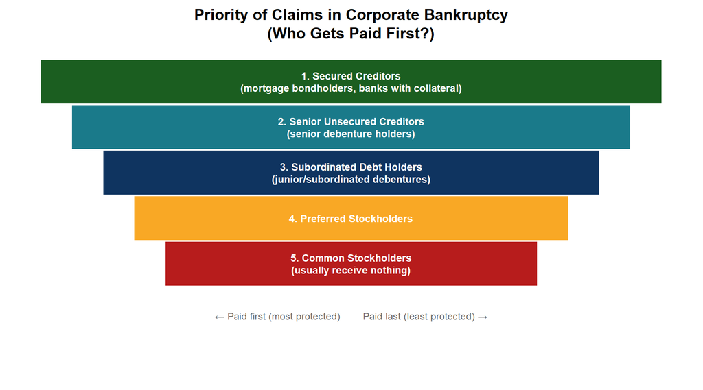

### Reading the Pyramid

**Secured creditors** are at the top — they have specific assets pledged to them. If the company’s factory is collateral for a mortgage bond, those bondholders get the factory first.

**Senior unsecured creditors** come next — they have no specific collateral but rank ahead of everyone else in the general pool of assets.

**Subordinated debtholders** come after senior unsecured — they specifically agreed to be junior in exchange for a higher coupon rate.

**Preferred stockholders** get whatever is left after all debt is paid. In practice, preferred stockholders rarely recover anything in a large bankruptcy.

**Common stockholders** are last. In most corporate bankruptcies, common stockholders receive **nothing**. The equity is wiped out.

**ImportantThe Golden Rule of Bankruptcy**

Bondholders must be paid in full before stockholders receive a single dollar. This is why bonds are considered less risky than stocks — even in a worst-case scenario, bondholders stand ahead of equity holders in the queue.

### A Real Example: Hertz (2020)

When Hertz filed for bankruptcy in May 2020 during the COVID-19 pandemic, its secured creditors (primarily banks with liens on the vehicle fleet) were eventually paid in full because the car fleet had real tangible value. Unsecured bondholders recovered a portion of their investment. Common stockholders initially appeared wiped out — the stock fell to nearly zero. (In an unusual twist, a Reddit-driven short squeeze later gave Hertz stockholders a partial recovery, but this is the rare exception, not the rule.)

## Credit Ratings: The Report Card for Bonds

Credit rating agencies — **Moody’s**, **Standard & Poor’s (S&P)**, and **Fitch** — assess the creditworthiness of bond issuers and assign ratings that tell investors how likely the company is to default.

Credit Rating Scale — S&P/Fitch and Moody’s

| S&P / Fitch | Moody’s | Category | Meaning |
| --- | --- | --- | --- |
| AAA | Aaa | Investment Grade | Highest quality — minimal credit risk |
| AA | Aa | Investment Grade | Very high quality — very low credit risk |
| A | A | Investment Grade | High quality — low credit risk |
| BBB | Baa | Investment Grade | Good quality — moderate credit risk |
| BB | Ba | High Yield / Junk | Speculative — significant credit risk |
| B | B | High Yield / Junk | Highly speculative — high credit risk |
| CCC | Caa | High Yield / Junk | Very high risk — near default |
| D | C | Default | In default |

### Investment Grade vs High Yield

The dividing line between **BBB** (Baa) and **BB** (Ba) is one of the most important in finance. Bonds rated BBB and above are **investment grade** — pension funds, insurance companies, and many mutual funds are legally required to hold only investment-grade bonds.

Bonds rated BB and below are **high yield** — also called **junk bonds** (a term coined somewhat pejoratively in the 1970s, though the industry prefers “high yield”). They offer higher coupons to compensate for higher default risk.

When a bond is downgraded from BBB to BB — called **falling to junk** or becoming a **fallen angel** — institutional investors who can only hold investment-grade bonds are forced to sell. This forced selling can cause the bond price to drop sharply even if the company’s fundamentals haven’t changed dramatically.

## Call and Put Provisions

Not every bond simply pays coupons until maturity. Many bonds have optional early redemption features.

### Callable Bonds

A **callable bond** gives the **company** the right to redeem (pay off) the bond before maturity at a specified price. Companies use this when interest rates fall — they call in the old high-coupon bonds and reissue at lower rates, just like a homeowner refinancing a mortgage.

For investors, callable bonds are less desirable — just when rates fall and the bond would rise in price, the company calls it away. Investors demand a higher coupon to accept call risk.

### Puttable Bonds

A **puttable bond** gives the **investor** the right to sell the bond back to the company at face value before maturity. This protects investors if rates rise — rather than holding a low-coupon bond that has dropped in price, they can put it back and reinvest at higher rates. Companies pay for this feature by issuing at a lower coupon.

### Make-Whole Call

Many investment-grade bonds include a **make-whole call** provision — the company can call the bond but must pay investors the present value of all remaining cash flows discounted at a very low rate (typically Treasury + 25-50 bp). In practice this makes calling the bond very expensive and the provision rarely gets exercised.

## Key Terms Every Bond Investor Should Know

| Term | Definition |
| --- | --- |
| **Face value / Par value** | The amount repaid at maturity, typically $1,000 |
| **Coupon rate** | The annual interest rate stated on the bond |
| **Yield to maturity (YTM)** | The total return if held to maturity — accounts for price paid |
| **Current yield** | Annual coupon / current price — a simpler but less complete measure |
| **Clean price** | The quoted price excluding accrued interest |
| **Dirty price** | Clean price + accrued interest — what you actually pay |
| **Duration** | How sensitive the bond price is to yield changes |
| **Credit spread** | The extra yield over Treasuries that compensates for credit risk |
| **Investment grade** | Rated BBB/Baa or above — considered relatively safe |
| **High yield / Junk** | Rated BB/Ba or below — higher risk, higher coupon |
| **Callable** | Company can redeem early — less valuable to investor |
| **Indenture** | The legal contract governing the bond |
| **Trustee** | The bank that monitors covenant compliance for bondholders |
| **Covenant** | Rules the company must follow while the bond is outstanding |
| **Default** | Failure to make a coupon or principal payment on time |

## Why Do Companies Issue Bonds Instead of Stock?

A natural question: if a company needs money, why not just issue more stock? Several reasons make bonds attractive:

**1. Cost** — Interest on bonds is **tax-deductible**. Dividends on stock are not. A company in the 25% tax bracket paying 5% interest on bonds effectively pays only 3.75% after the tax deduction. Equity has no such advantage.

**2. Control** — Issuing more stock dilutes existing shareholders’ ownership percentage. Issuing bonds does not. The existing owners retain full control.

**3. Signal** — A company confident in its future cash flows is willing to take on fixed interest obligations. Issuing bonds can signal management confidence. Issuing stock sometimes signals management thinks the stock is overvalued.

**4. Matching** — Long-term projects (a 30-year bridge, a power plant) are naturally financed with long-term debt that matches the asset’s useful life.

## Summary: What Makes a Bond a Bond?

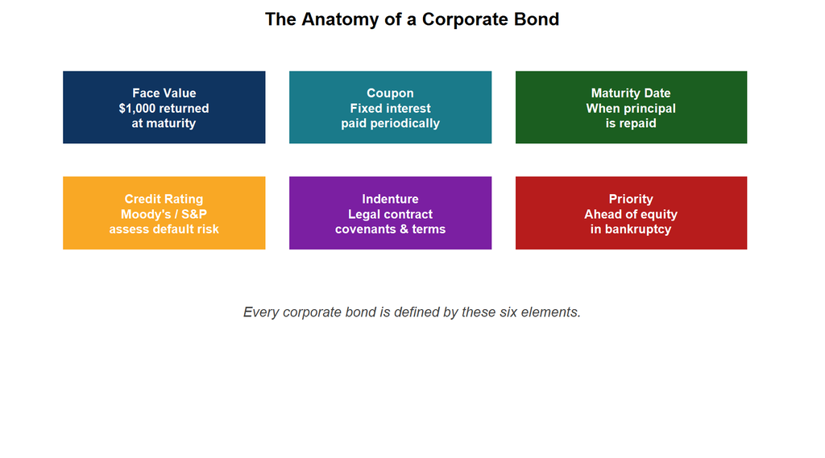

A bond is one of the most fundamental instruments in finance. It is predictable, contractual, and senior to equity in every way that matters. Understanding bonds — how they are priced, how they behave when rates move, and where they sit in a company’s capital structure — is essential knowledge for any investor, accountant, or finance professional.

The companion tutorials in this series use the **FinancialFunctions** package to price bonds, calculate duration and convexity, and build amortization tables — putting the concepts in this primer to work with real numbers.